# Statistical testing

#Statistical testing 23-01-2023 #This Notebook will carry out Differential abundance testing and statistical testing of infSILAC proteomics from my HepG2 OOPS RBPome samples. #See previous notebook on Data processing and QC for experimental setup.

```r
library(camprotR)
library(ggplot2)
library(MSnbase)
library(DEqMS)
library(limma)
library(dplyr)
library(tidyr)
library(ggplot2)
library(broom)
library(biobroom)
library(here)
library(uniprotREST)
library(Proteomics.analysis.data)
```

```r
prot_res <- readRDS(here('results/prot_res.rds'))

# Find the columns (samples) where the label swap is CL = H
label_swap_h <- pData(prot_res)$label_swap == 'CL=H'

if(!any(label_swap_h)){
  error('error message here')
}

# The others must be CL=L
label_swap_l <- !label_swap_h

# Find the rows where the CL=H samples have at least two finite (non-NA) values
keep_h <- rowSums(is.finite(exprs(prot_res[,label_swap_h]))) >= 2

# Find the rows where the CL=L samples have at least two finite (non-NA) values
keep_l <- rowSums(is.finite(exprs(prot_res[,label_swap_l]))) >= 2

table(keep_l & keep_h)
```

```
FALSE  TRUE
  720  1380
```

```r
# Filter the proteins to the rows where both the CL=H and CL=L side of the label
# swap have at least two finite values
prot_res_flt <- prot_res[(keep_l & keep_h),]

table(rowSums(is.na(prot_res_flt)))
```

```
  0   1   2   3   4   5   6   7   8   9  10  11  12
620 142  81  52  72  54  49  50  56  55  54  55  40
```

```r
#1380/2100 proteins retained after filtering
```

The maximum (unadjusted) ratio should be 0. Any ratio above this is because of measurement error (in the MS), incomplete heavy isotope incorporation, or inaccurate plate mixing (different numbers of cells).

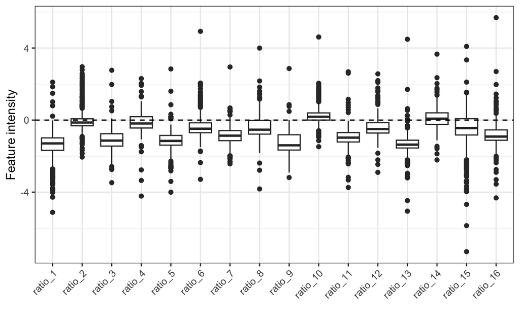

```r
plot_quant(prot_res_flt[,order(pData(prot_res_flt)$Replicate)]) +
  geom_hline(yintercept=log2(1/1), linetype=2)
```

There is a lot of variation in the distribution of ratios between the experiment, with the even replicates (CL=L) having consistently higher ratios (aside from replicate 16). Even within one half of the label swap, there is a lot of variation. We can separate the sample by their annotations to explore this futher (see below). The green line is the expected maximum value for a true RBP and the black line is the expected minimum value for a non RBP. However, values can fall outside these bounds due to measurement error, incomplete incorporation and/or unbalanced cell numbers for each isotope.

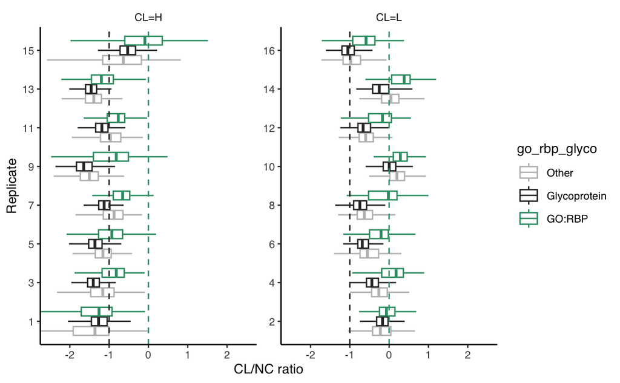

```r
prot_res_flt_long <- tidy(prot_res_flt, addPheno =TRUE) %>%
  merge(fData(prot_res_flt),by.x='protein', by.y='row.names')
p <- prot_res_flt_long %>%
  filter(go_rbp_glyco!='GO:RBP & glycoprotein') %>%
  ggplot(
            aes(factor(Replicate, levels=1:16), value, colour=go_rbp_glyco, group=interaction(go_rbp_glyco, Replicate))) +
  geom_boxplot(outlier.shape = NA) +
  scale_colour_manual(values=c('grey', 'grey20', get_cat_palette(3)[c(3,2)])) +
  facet_wrap(~label_swap, scales='free') +
  theme_camprot(base_size=10, base_family='sans', aspect_square=FALSE, border=FALSE) +
  geom_hline(yintercept=log2(1/1), linetype=2, colour=get_cat_palette(3)[3]) +
  geom_hline(yintercept=log2(1/2), linetype=2, colour='grey20') +
  theme(strip.background=element_blank()) +
  ylab('CL/NC ratio') +
  xlab('Replicate') +
  coord_flip(ylim=c(-2.5, 2.5))


print(p)
```

Now that we have included the annotation, we can see that although there is a large variation in the ratio distributions between the experiments, in almost all experiments, the GO:RBPs have higher ratios.

Since glycoproteins should not have higher abundance upon CL and should have their CL/NC ratio centered at 0, we can use this prior expectation to adjust the ratio. Following this adjustment, our null hypothesis in the downstream statistical testing is that the protein has the same CL/NC enrichment as a typical glycoprotein, which should not be enriched by CL.

See https://mrctoxbioinformatics.github.io/Proteomics_data_analysis/Markdowns/LFQ_alternative_normalisation.html for code to do this ratio adjustment. Once the ratios have been adjusted, we can proceed with the statistical testing as previously.

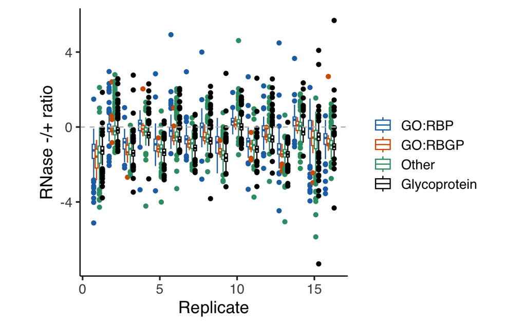

```r
# insert code for adjustment here...
fData(prot_res_flt) <- fData(prot_res_flt) %>%
  mutate(Glycoprotein = rownames(prot_res_flt) %in% glycoproteins) %>%
  mutate(GO.RBP = rownames(prot_res_flt) %in% rbps) %>%
  mutate(Glyco.RBP = interaction(Glycoprotein, GO.RBP)) %>%
  mutate(Glyco.RBP = factor(recode(
    Glyco.RBP,
    'TRUE.TRUE'='GO:RBGP',
    'FALSE.TRUE'='GO:RBP',
    'TRUE.FALSE'='Glycoprotein',
    'FALSE.FALSE'='Other'),
    levels = c('GO:RBP', 'GO:RBGP', 'Other', 'Glycoprotein'))
  )

plot_ratios <- function(obj) {
  to_plot <- merge(
    exprs(obj),
    fData(obj)[,'Glyco.RBP',drop = FALSE],
    by = 'row.names'
  ) %>%
    pivot_longer(cols = -c(Row.names, Glyco.RBP), names_to = 'sample', values_to = 'ratio') %>%
    merge(pData(obj), by.x = 'sample', by.y = 'row.names') %>%
    filter(is.finite(ratio))

  p <- to_plot %>%
    ggplot(aes(x = Replicate, y = ratio,
               group = interaction(Glyco.RBP, Replicate),
               colour = factor(Glyco.RBP))) +
    geom_boxplot(position = position_dodge()) +
    theme_camprot(border = FALSE, base_family = 'sans', base_size = 15) +
    scale_colour_manual(values = c(get_cat_palette(3), 'black'), name = '') +
    geom_hline(yintercept = 0, linetype = 2, colour = 'grey') +
    labs(
      x = "Replicate",
      y = "RNase -/+ ratio"
    )

  print(p)

  invisible(to_plot)
}

plot_ratios(prot_res_flt)
```

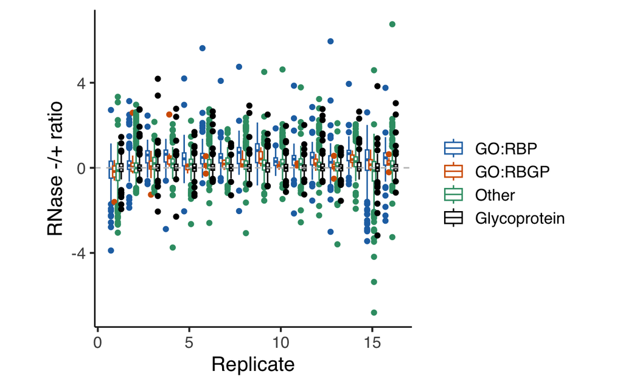

```r
glycoprotein_medians <- prot_res_flt[fData(prot_res_flt)$Glyco.RBP == 'Glycoprotein',] %>%
  camprotR::get_medians()

prot_res_flt_adj <- camprotR::center_normalise_to_ref(
  prot_res_flt,
  glycoprotein_medians,
  center_to_zero = TRUE, # We want to center the glycoproteins around zero
  on_log_scale = TRUE # The quantifications are on a log scale (log2 ratios)
)

plot_ratios(prot_ratios_norm)
```

Below, we check that the normalisation has worked as desired.

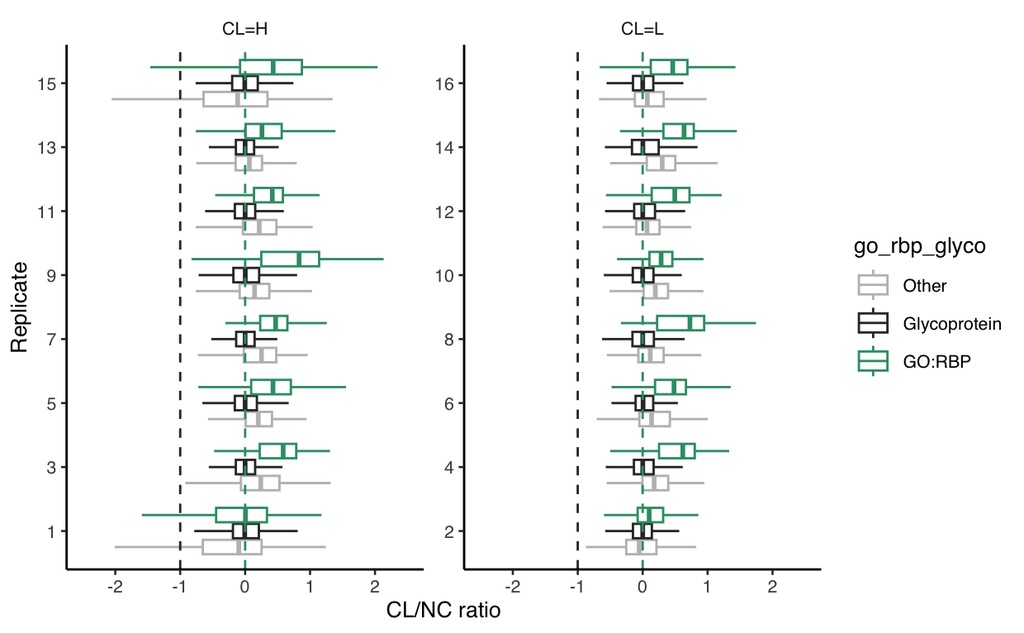

```r
prot_res_flt_adj_long <- tidy(prot_res_flt_adj, addPheno =TRUE) %>%
  merge(fData(prot_res_flt),by.x='protein', by.y='row.names')

p <- prot_res_flt_adj_long %>%
  filter(go_rbp_glyco!='GO:RBP & glycoprotein') %>%
  ggplot(
            aes(factor(Replicate, levels=1:16), value, colour=go_rbp_glyco, group=interaction(go_rbp_glyco, Replicate))) +
  geom_boxplot(outlier.shape = NA) +
  scale_colour_manual(values=c('grey', 'grey20', get_cat_palette(3)[c(3,2)])) +
  facet_wrap(~label_swap, scales='free') +
  theme_camprot(base_size=10, base_family='sans', aspect_square=FALSE, border=FALSE) +
  geom_hline(yintercept=log2(1/1), linetype=2, colour=get_cat_palette(3)[3]) +
  geom_hline(yintercept=log2(1/2), linetype=2, colour='grey20') +
  theme(strip.background=element_blank()) +
  ylab('CL/NC ratio') +
  xlab('Replicate') +
  coord_flip(ylim=c(-2.5, 2.5))


print(p)
```

```r
silac_protein_tidy <- prot_res_flt_adj %>%
  biobroom::tidy.MSnSet() %>%
  filter(is.finite(value))
```

```r
example_protein <- 'O00151'

silac_protein_tidy_example <- silac_protein_tidy %>%
  filter(protein==example_protein)

print(silac_protein_tidy_example)
```

| protein | sample.id | value |
| --- | --- | --- |
| O00151 | ratio_1 | -1.18019908 |
| O00151 | ratio_10 | 0.28355468 |
| O00151 | ratio_11 | 0.02680923 |
| O00151 | ratio_12 | 0.28062868 |
| O00151 | ratio_13 | -0.47862866 |
| O00151 | ratio_14 | 0.35739288 |
| O00151 | ratio_16 | 0.49499415 |
| O00151 | ratio_2 | 0.34972408 |
| O00151 | ratio_3 | 0.34642226 |
| O00151 | ratio_4 | 0.39980680 |

[output cut: 5 more lines]

```r
#O00151 1     -2.44304344
#O00151 11  -1.15763179
#O00151 13  -0.38174502
#O00151 16  -1.93439245
```

```r
t.test.res <- t.test(silac_protein_tidy_example$value,
                     alternative='two.sided')

print(t.test.res)
```

```
    One Sample t-test

data:  silac_protein_tidy_example$value
t = 1.5545, df = 14, p-value = 0.1424
alternative hypothesis: true mean is not equal to 0
95 percent confidence interval:
 -0.0696055  0.4361822
sample estimates:
mean of x
0.1832884
```

```r
#data:  silac_protein_tidy_example$value
#t = 1.088, df = 11, p-value = 0.2999
#alternative hypothesis: true mean is not equal to 0
#95 percent confidence interval:
# -0.07797883  0.23043178
#sample estimates:
# mean of x
#0.07622647
```

```r
tidy(t.test.res)
```

| estimate | statistic | p.value | parameter | conf.low | conf.high | method | alternative |
| --- | --- | --- | --- | --- | --- | --- | --- |
| 0.1832884 | 1.554464 | 0.1423838 | 14 | -0.0696055 | 0.4361822 | One Sample t-test | two.sided |

```r
NA
```

```r
t.test.res.all <- silac_protein_tidy %>% group_by(protein) %>%
  do(tidy(t.test(.$value, alternative='two.sided')))
```

```
|============================== |100% ~0 s remaining
```

```r
print(t.test.res)
```

```
    One Sample t-test

data:  silac_protein_tidy_example$value
t = 1.5545, df = 14, p-value = 0.1424
alternative hypothesis: true mean is not equal to 0
95 percent confidence interval:
 -0.0696055  0.4361822
sample estimates:
mean of x
0.1832884
```

```
#>
#>
#>  One Sample t-test
```

```r
#data:  silac_protein_tidy_example$value
#t = 1.088, df = 11, p-value = 0.2999
#alternative hypothesis: true mean is not equal to 0
#95 percent confidence interval:
# -0.07797883  0.23043178
#sample estimates:
# mean of x
#0.07622647
t.test.res.all %>% filter(protein==example_protein)
```

| protein | estimate | statistic | p.value | parameter | conf.low | conf.high | method | alternative |
| --- | --- | --- | --- | --- | --- | --- | --- | --- |
| O00151 | 0.1832884 | 1.554464 | 0.1423838 | 14 | -0.0696055 | 0.4361822 | One Sample t-test | two.sided |

```r
NA
```

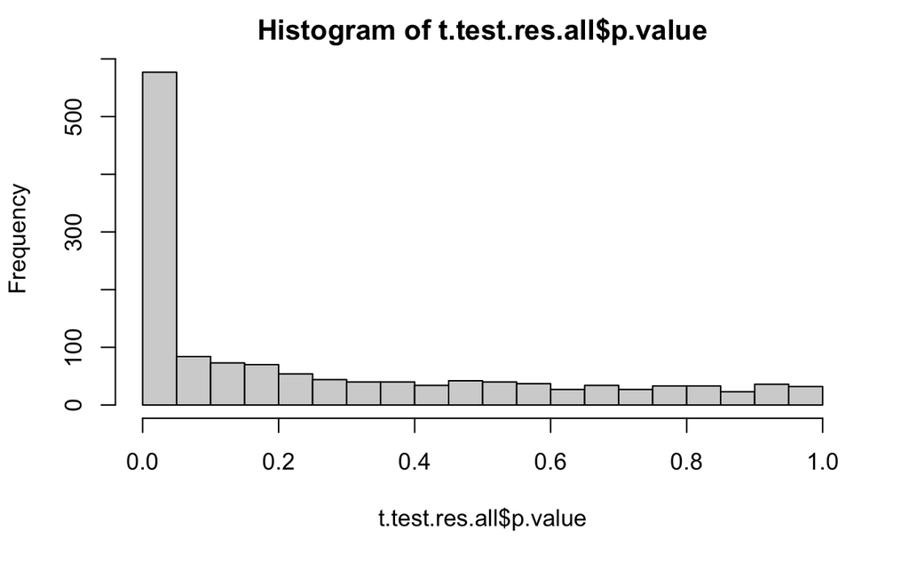

```r
hist(t.test.res.all$p.value, 20)
```

```r
t.test.res.all$padj <- p.adjust(t.test.res.all$p.value, method='BH')
table(t.test.res.all$padj<0.05)
```

```
FALSE  TRUE
  914   466
```

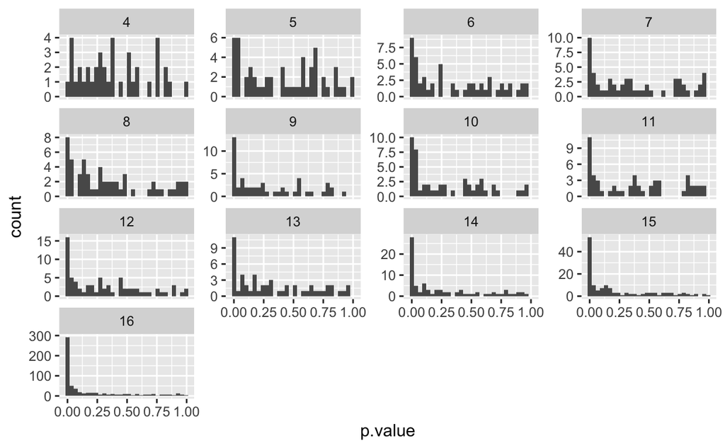

```r
prot_count<- rowSums(is.finite(exprs(prot_res_flt_adj)))
prot_count_df <- data_frame(prot_count)
everything <-cbind(t.test.res.all, prot_count_df)

ggplot(everything, aes(p.value)) + geom_histogram() + facet_wrap(~prot_count,scales="free_y")
```

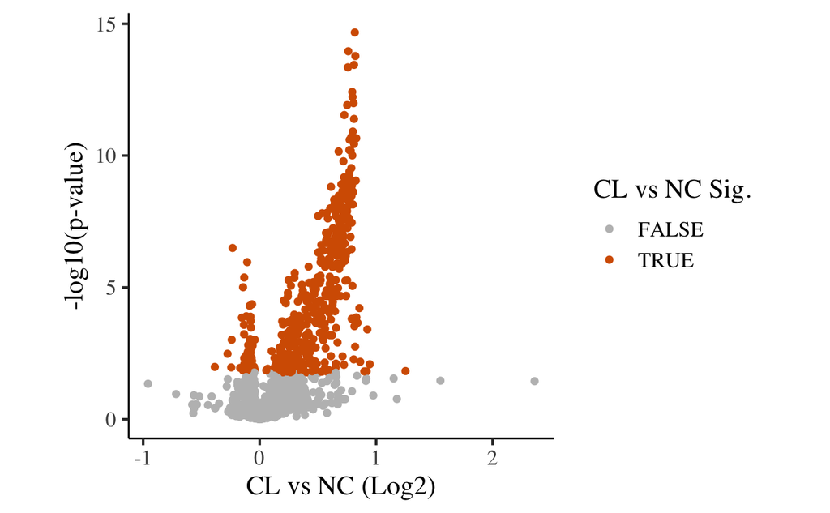

```r
t.test.res.all %>%
  ggplot(aes(x = estimate, y = -log10(p.value), colour = padj < 0.05)) +
  geom_point() +
  theme_camprot(border=FALSE, base_size=15) +
  scale_colour_manual(values = c('grey', get_cat_palette(2)[2]), name = 'CL vs NC Sig.') +
  labs(x = 'CL vs NC (Log2)', y = '-log10(p-value)')
```

```r
dat <- prot_res_flt_adj %>%
  exprs()

# Performing the equivalent of a one-sample t-test, so the design matrix is just an intercept
design <- cbind(Intercept = rep(1, ncol(dat)))

fit <- lmFit(dat, design)
efit <- eBayes(fit, trend =TRUE)
```

Not a great relationship between the average expression (here the modified log2 ratio) and the variance. Makes sense that these two shouldn’t be related. Better to switch to DEqMS, which looks for an association between the number of peptides and the variance.

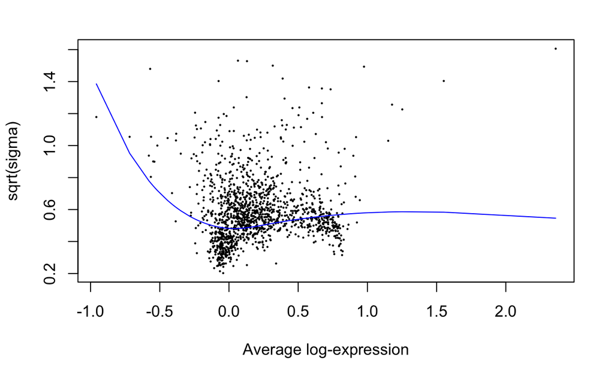

```r
limma::plotSA(efit)
```

```r
#protein_ratio_long <- prot_res_flt_adj %>%
#  exprs() %>%
#  data.frame() %>%
#  tibble::rownames_to_column('Master.Protein.Accessions') %>%
#  pivot_longer(cols=-Master.Protein.Accessions, values_to = 'protein_ratio', names_to = 'sample')


protein_ratio <- prot_res_flt_adj %>%
  exprs()

protein_ratio_df <- data.frame(protein_ratio)

protein_ratio_long<-protein_ratio_df %>%
  tibble::rownames_to_column('Master.Protein.Accessions') %>%
  pivot_longer(cols=-Master.Protein.Accessions, values_to='protein_ratio', names_to='sample') %>%
  mutate(sample=remove_x(sample))

pep_res <- readRDS(here('results/pep_res_flt.rds'))

# Obtain the min peptide count across the samples and determine the minimum value across
# samples
min_pep_count <- camprotR::count_features_per_protein(pep_res) %>%
  merge(protein_ratio_long,  by=c('Master.Protein.Accessions','sample')) %>%
  filter(is.finite(protein_ratio)) %>%  # We only want to consider samples with a ratio quantified
  group_by(Master.Protein.Accessions) %>%
  summarise(min_pep_count = min(n))

# add the min peptide count
efit$count <- min_pep_count$min_pep_count
```

```r
# run DEqMS
efit_deqms <- suppressWarnings(spectraCounteBayes(efit))
```

A better relationship, even if it is still weak. Only real difference is higher variance for very low minimum peptides.

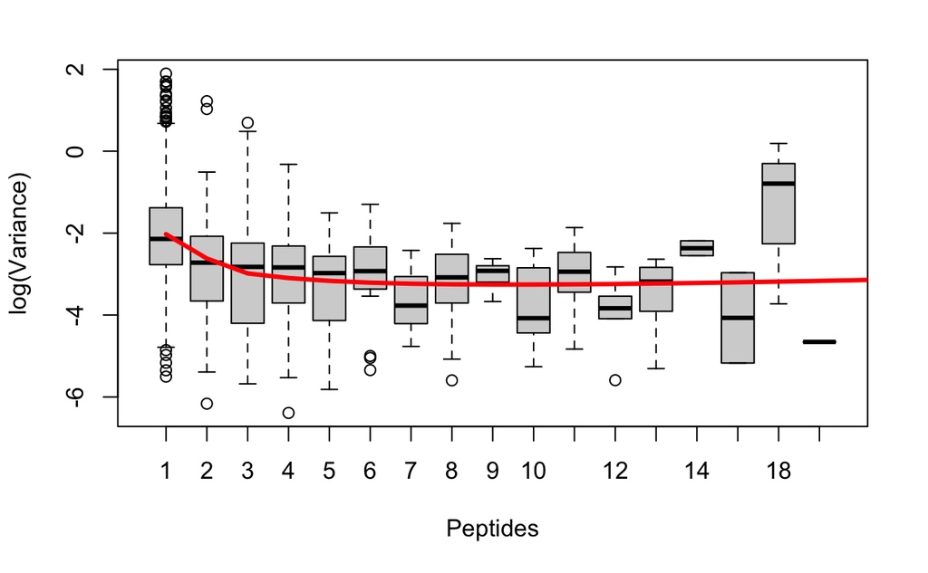

```r
# Diagnostic plots
VarianceBoxplot(efit_deqms,xlab = "Peptides")
```

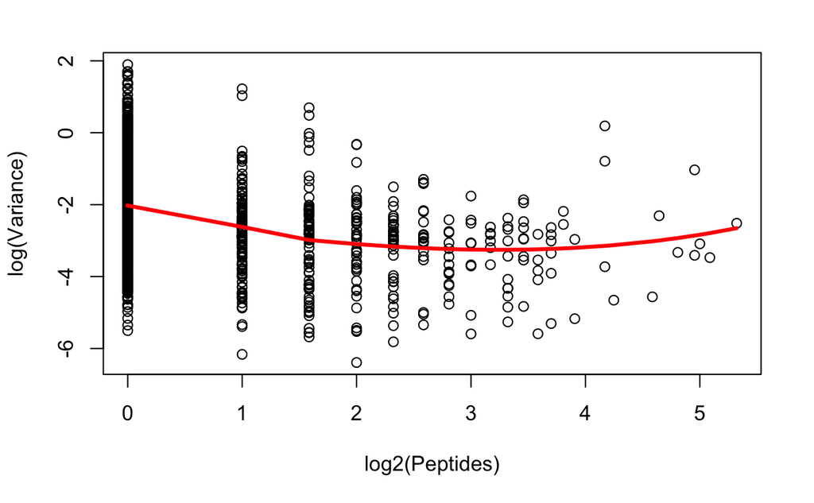

```r
VarianceScatterplot(efit_deqms, xlab = "log2(Peptides)", )
```

```r
log2(18)
```

```
[1] 4.169925
```

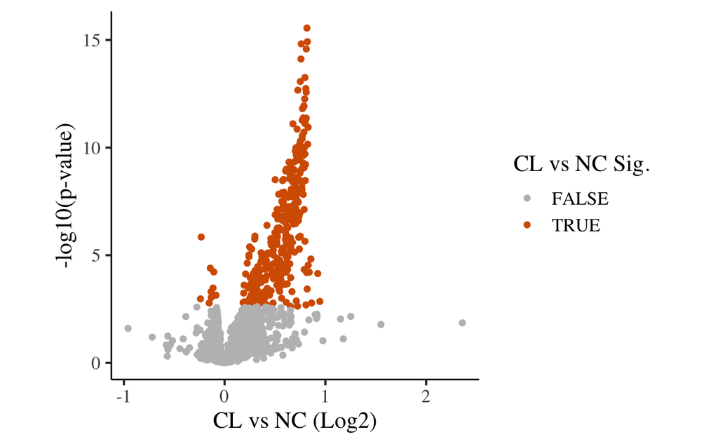

```r
deqms_results <- outputResult(efit_deqms, coef_col = 1)

deqms_results %>%
  ggplot(aes(x = logFC, y = -log10(sca.P.Value), colour = sca.adj.pval < 0.01)) +
  geom_point() +
  theme_camprot(border=FALSE, base_size=15) +
  scale_colour_manual(values = c('grey', get_cat_palette(2)[2]), name = 'CL vs NC Sig.') +
  labs(x = 'CL vs NC (Log2)', y = '-log10(p-value)')
```

```r
head(deqms_results)
```

|  | logFC | AveExpr | t | P.Value | adj.P.Val | B | gene | count | sca.t | sca.P.Value | sca.adj.pval |
| --- | --- | --- | --- | --- | --- | --- | --- | --- | --- | --- | --- |
| Q13148 | 0.8169809 | 0.8169809 | 21.90098 | 5.026049e-14 | 6.935948e-11 | 22.40589 | Q13148 | 5 | 29.14666 | 2.798882e-16 | 3.862458e-13 |
| Q9UKM9 | 0.8214662 | 0.8214662 | 20.70512 | 1.279495e-13 | 7.281881e-11 | 21.49961 | Q9UKM9 | 10 | 26.76993 | 1.202239e-15 | 6.969519e-13 |
| P07910 | 0.7606451 | 0.7606451 | 20.25064 | 1.849240e-13 | 7.281881e-11 | 21.14031 | P07910 | 5 | 26.41024 | 1.515113e-15 | 6.969519e-13 |
| Q15717 | 0.8103374 | 0.8103374 | 20.08973 | 2.110690e-13 | 7.281881e-11 | 21.01104 | Q15717 | 7 | 25.58387 | 2.607738e-15 | 8.996697e-13 |
| Q96T37 | 0.7576836 | 0.7576836 | 19.39792 | 3.769279e-13 | 1.040321e-10 | 20.44252 | Q96T37 | 3 | 24.01681 | 7.656364e-15 | 2.113156e-12 |
| Q92879 | 0.7975838 | 0.7975838 | 18.07167 | 1.210408e-12 | 2.386233e-10 | 19.29115 | Q92879 | 3 | 21.36762 | 5.552100e-14 | 1.276983e-11 |

```r
colnames(t.test.res.all) <- paste0('t.test.', colnames(t.test.res.all))
colnames(deqms_results) <- paste0('deqms.', colnames(deqms_results))
```

```r
silac_compare_tests <- merge(deqms_results,
      t.test.res.all,
      by.x='row.names',
      by.y='t.test.protein')
```

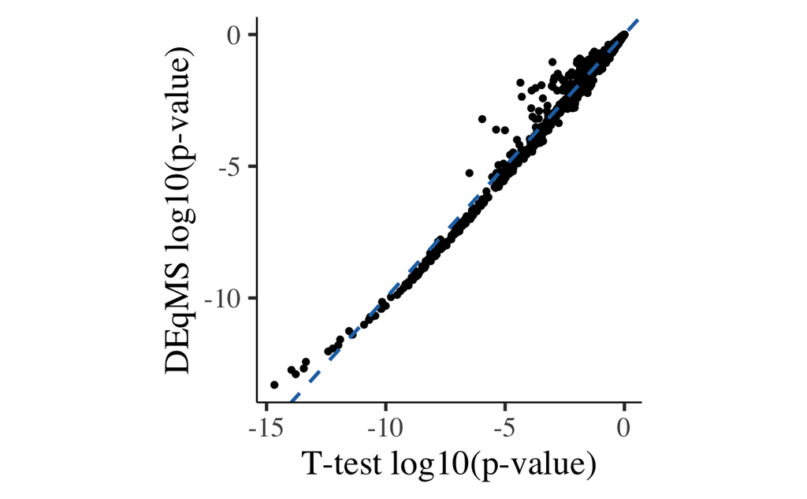

```r
p <- ggplot(silac_compare_tests) +
  aes(log10(t.test.p.value), log10(deqms.P.Value)) +
  geom_point() +
  geom_abline(slope=1, linetype=2, colour=get_cat_palette(1), size=1) +
  theme_camprot(border=FALSE) +
  labs(x='T-test log10(p-value)', y='DEqMS log10(p-value)')
print(p)
```

```r
NA
NA
```

As expected, p-values from the t-test and modified t-test (that’s basically what DEqMS is in this parameterisation) are well correlated, but generally slightly lower for DEqMS.

```r
silac_compare_tests %>%
  group_by(t.test.padj<0.05,
           deqms.sca.adj.pval<0.05) %>%
  tally()
```

| t.test.padj < 0.05 | deqms.sca.adj.pval < 0.05 | n |
| --- | --- | --- |
| FALSE | FALSE | 894 |
| FALSE | TRUE | 20 |
| TRUE | FALSE | 22 |
| TRUE | TRUE | 444 |

```r
NA
NA
```

```r
 # Saving to R binary format. Can read back into memory with readRDS().
saveRDS(silac_compare_tests, here('results/SILAC_tests.rds'))

# Saving to tab-separated (human-readable) flatfile
write.table(silac_compare_tests, here('SILAC_tests.tsv'), sep='\t', row.names=FALSE)
```